# Rapport Projet PMS

EL GOUIJ Faical, DEGROS Antonin, MOUNIER Leo

2025-04-04

## Partie 1. Tirage avec remise

**Question 1**
$$E(X) = \displaystyle \sum_{k=1}^{\theta}kP(X=k)=
\frac{1}{\theta}\sum_{k=1}^{\theta}=
\frac{1}{\theta}\frac{\theta(\theta+1)}{2}= \frac{\theta + 1}{2}.$$

$V(X) = E((X-E(X))^2) = E(X^2) - E(X)^2.$ Par transfert :

$E(X^2) = \displaystyle \sum_{k=1}^{\theta}k^2P(X=k) = \frac{1}{\theta}\frac{\theta (\theta+1)(2\theta + 1)}{6}$ par la formule de la somme des carrés.

Ainsi $V(X) = \frac{(\theta+1)(2\theta+1)}{6} -\left( \frac{\theta+1}{2} \right)^2 = \frac{\theta^2-1}{12}$ après simplification.

**Question 2**

D’après 1, E(X) = $\phi(\theta)$ avec $\phi : t \rightarrow \frac{t+1}{2}$. Ainsi l’estimateur des moments de $\theta$ est :

$$\tilde\theta_n = \phi^{-1}(\bar X_n) = 2\bar X_n -1 =
\frac{2}{n}\displaystyle\left(\sum_{k=1}^{n}X_k\right) - 1.$$

Il en suit alors :

$$E(\tilde\theta_n) = \frac2n\displaystyle\sum_{k=1}^nE(X_k) -1 =
2E(X)-1=\theta.$$

Ainsi $\tilde\theta_n$ est sans biais. On calcule maintenant sa variance :

$$V(\tilde \theta_n) =
V\left(\frac{2}{n}\displaystyle\left(\sum_{k=1}^{n}X_k\right) - 1\right)
\\
= \frac{4}{n^2}\sum_{k=1}^nV(X_k)\\
= \frac{4V(X)}{n}$$

Ce qui nous donne $V(\tilde\theta_n) = \frac{\theta^2-1}{3n}$ après simplifications. La variance de la somme est la somme des variances en vertu de l’indépendance des $X_k$.

**Question 3**

On a : $\forall x \in \mathbb R : F_X(x) = P(X \leq x) = 0$ si x < 1, $F(x) = \displaystyle \sum_{k=1}^{\lfloor x \rfloor}P(X=k)$ si $x \in [1,\theta]$ et F(x) = 1 sinon. Finalement, on a $\forall x \in \mathbb R : F(x) = \mathbb 1_{[1,\theta]}(x) \frac{\lfloor x \rfloor}{\theta} + \mathbb 1_{]\theta,+\infty[}(x)$.

La médiane de la loi de X est un réel m tel que $P(X \leq m) = P(X\geq m) = \frac12$.

Si m $\not \in [1,\theta]$ on obtient soit 0 = $\frac12$ soit 1 = $\frac12$, ce qui est absurde. Ainsi m $\in [1,\theta]$. On a alors $\lfloor x \rfloor = \frac{\theta}{2}$, d’où $\frac{\theta}{2} \leq m \lt \frac{\theta}{2} + 1$. Par convention on prend le milieu de ces deux points, ce qui donne m = $\frac{\theta+1}{2}$.

On en déduit $\tilde\theta_n' = 2X^*_{\frac{n+1}{2}} - 1$ si n est impair et $\tilde\theta_n' = X^*_{\frac{n}{2}} + X^*_{\frac{n}2 + 1} - 1$ sinon.

**Question 4**

On a $\forall x \in \mathbb R : P(X_n^* \leq x) = \displaystyle \prod_{k=1}^n P(X_k \leq x)$ par indépendance, d’où $P(X_n^* \leq x) = (F_X(x))^n.$ Pour expliciter, on a donc $F_{X_n^*}(x) = 0$ si x < 1, $F_{X_n^*}(x) = \left( \frac{\lfloor x \rfloor}{\theta} \right)^n$ si $x \in [1,\theta]$ et $F_{X_n^*}(x) = 1$ sinon.

De plus, on a $\forall k \in \left\{1,...,\theta \right\}: P(X_n^* \leq k) =\displaystyle \prod_{i=1}^n P(X_i \leq k) = P(X\leq k)^n = \left( \frac{k}{\theta} \right)^n$. On en déduit :

$$\forall k \in \left\{2,...,\theta \right\} : P(X_n^* = k) = P(X_n^* \leq
k) - P(X_n^* \leq k-1) = \frac{1}{\theta^n}(k^n - (k-1)^n).$$

On calcule directement $P(X_n^* = 1) = \frac1{\theta^n}$, ce qui permet de conclure que la formule précédente s’applique aussi à k = 1.

**Question 5**

La vraisemblance des observations est, par indépendance :

$$\mathscr L(\theta;x_1,...,x_n) = \displaystyle \prod_{i=1}^nP(X= x_i
;\theta)\\
= \prod_{i=1}^n\frac1{\theta} \mathbb 1_{\{1,...,\theta\}}(x_i)\\
= \frac1{\theta^n}\mathbb 1_{\{1,...,\theta\}^n}(x_1,...,x_n).$$

Ainsi la vraissemblance est nulle si $\theta < max(x1,...,x_n)$ et vaut $\frac1{\theta^n}$ sinon. Son maximum est donc atteint pour $\theta = max(x_1,...,x_n) = x_n^*$, d’où l’EMV $\hat \theta_n = X_n^*$. De plus :

$$E(\hat{\theta}_n) = E(X_n^*) = \sum_{k=1}^{\theta} k P(X_n^* = k)\\
= \sum_{k=1}^{\theta} k \left( \left(\frac{k}{\theta} \right)^n -
\left(\frac{k-1}{\theta} \right)^n \right)
\\
= \frac{1}{\theta^n} \left( \sum_{k=1}^{\theta} k^{n+1} -
\sum_{k=1}^{\theta} (k-1)^{n+1} - \sum_{k=1}^{\theta} (k-1)^n \right)
\\
= \frac{1}{\theta^n} \left( \theta^{n+1} + \sum_{k=1}^{\theta}
(k-1)^{n+1} - \sum_{k=1}^{\theta} (k-1)^n \right)
\\
= \theta + \frac{1}{\theta^n} \left( \sum_{k=1}^{n} (k-1)^n \right)
\\
\neq \theta$$

Donc l’estimateur est biaisé.

**Question 6**

Grâce au calcul précédent de la fonction de répartition de X, on peut déduire la relation : $\forall x \in [1,\theta] : F_X(x) = \frac1{\theta}\lfloor x \rfloor + 0$. On peut donc tracer le graphe de probabilités $(x_i^*,\frac{i}{n}), i \in \{1,...,n\}$ (les $x_i$ sont entiers donc pas besoin de leur appliquer la partie entière). Ainsi d’après la relation précédente, $\theta_g$ est la pente de la droite extrapolée par la disposition du nuage de points obtenu. La pente globale est calculée en prenant en compte les points extrêmes de la courbe, quon calcule avec R dans les questions suivantes.

**Question 7**

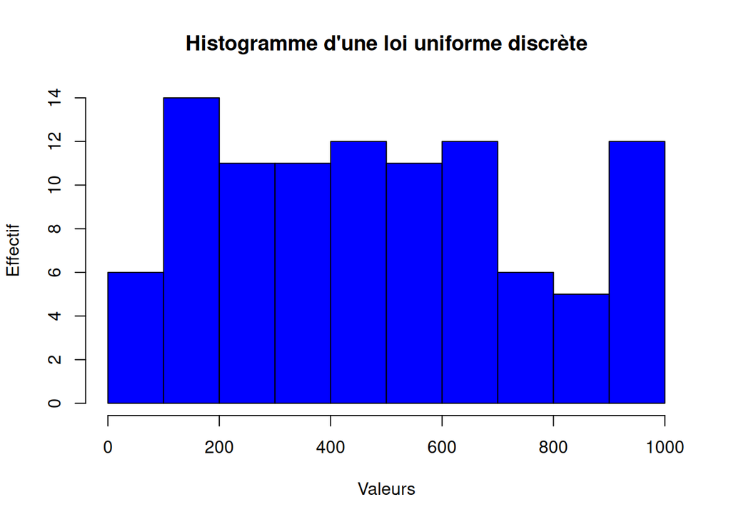

```r
theta <- 1000
n <- 100
échantillon <- sample(1:theta, n, replace = TRUE)
# L'histogramme
hist(échantillon,col= "blue", main = "Histogramme d'une loi uniforme discrète", xlab = "Valeurs", ylab= "Effectif")
```

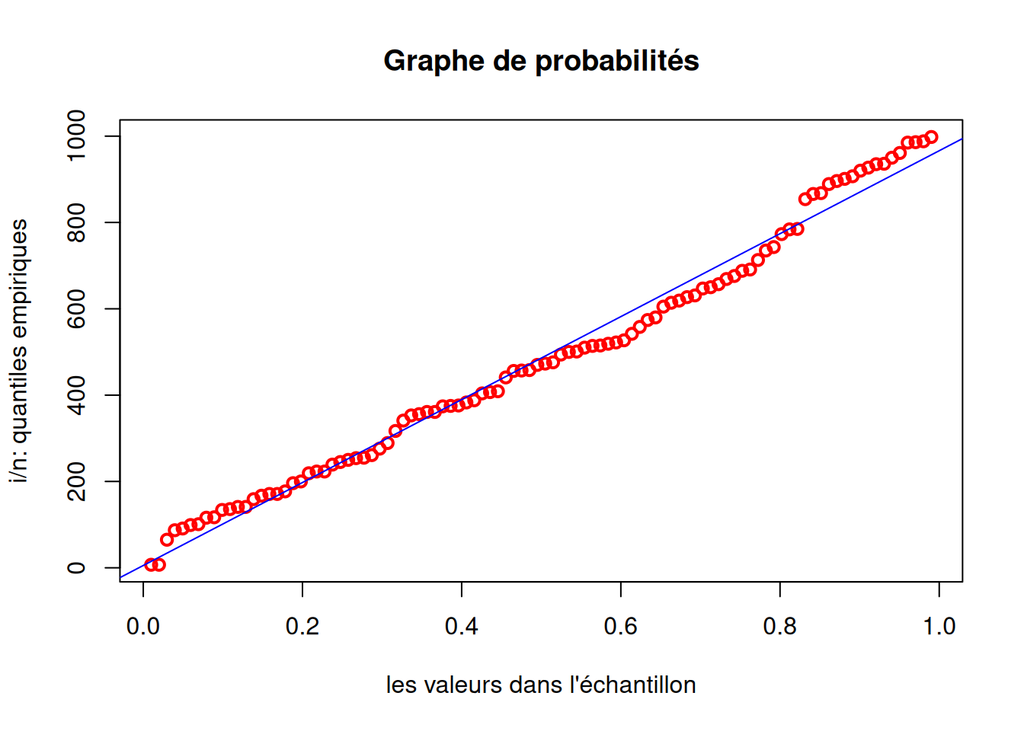

```r
#Définition des estimateurs
moments <- 2 * mean(échantillon) - 1
mediane <- 2 * median(échantillon) - 1
max_vrais <- max(échantillon)

#Etimateur θ_g; Graphe de Probabilité

échantillon_trie = sort(échantillon)
quantiles = (1:n)/(n+1)
plot(quantiles, échantillon_trie, col = "red",main = "Graphe de probabilités", lwd = 2,xlab = "les valeurs dans l'échantillon", ylab = "i/n: quantiles empiriques")

regression_lineaire <- lm(échantillon_trie ~ quantiles)
abline(regression_lineaire, col= "blue")
```

```r
pente <- coef(regression_lineaire)[2]  #obtenir la pente avec regression linéaire
theta_g = 1/pente
theta_g
```

```
##   quantiles
## 0.001040745
```

```r
theta_chap <- (max_vrais^(n + 1) - (max_vrais - 1)^(n + 1)) / (max_vrais^n - (max_vrais - 1)^n)

cat("Estimateur des moments:", moments, "\n")
```

```
## Estimateur des moments: 970.66
```

```r
cat("Estimateur basé sur la médiane:", mediane, "\n")
```

```
## Estimateur basé sur la médiane: 942
```

```r
cat("Estimateur du maximum de vraisemblance:", max_vrais, "\n")
```

```
## Estimateur du maximum de vraisemblance: 998
```

```r
cat("Estimateur graphique:", theta_g, "\n")
```

```
## Estimateur graphique: 0.001040745
```

```r
cat("Estimateur sans biais et de variance minimale:", theta_chap, "\n")
```

```
## Estimateur sans biais et de variance minimale: 1007.483
```

**Question 8**

```r
n <- 1000
for (m in 1:1000)
{
  échantillon <- sample(1:n,theta,replace=TRUE)


  #Définition des estimateurs
  append(moments,2 * mean(échantillon) - 1)
  append(mediane,2 * median(échantillon) - 1)
  append(max_vrais,max(échantillon))
  append(theta_g,max(échantillon) + min(échantillon) - 1)
  append(theta_chap,(max_vrais^(n + 1) - (max_vrais - 1)^(n + 1)) / (max_vrais^n - (max_vrais - 1)^n))

}


# Les Biais
cat ("biais_moments :",mean(moments) - theta, "\n")
```

```
## biais_moments : -29.34
```

```r
cat("biais_mediane : ",  mean(mediane) - theta,"\n")
```

```
## biais_mediane :  -58
```

```r
cat("biais_max_vrais : ", mean(max_vrais) - theta,"\n")
```

```
## biais_max_vrais :  -2
```

```r
cat("biais_g : ", mean(theta_g) - theta,"\n")
```

```
## biais_g :  -999.999
```

```r
cat("biais_chap : ", mean(theta_chap) - theta,"\n\n")
```

```
## biais_chap :  7.483352
```

```r
# Les erreurs quadratiques moyennes
cat("errure_moments : ",mean(((moments)-mean(moments))^2)+ (mean(moments) - theta)^2,"\n")
```

```
## errure_moments :  860.8356
```

```r
cat("Erreure_médiane : ",mean(((mediane)-mean(mediane))^2)+(mean(mediane) - theta)^2,"\n")
```

```
## Erreure_médiane :  3364
```

```r
cat("erreure_max_vrais : ",mean(((max_vrais)-mean(max_vrais))^2)+ (mean(max_vrais) - theta)^2,"\n")
```

```
## erreure_max_vrais :  4
```

```r
cat("errure_g : ",mean(((theta_g)-mean(theta_g))^2)+(mean(theta_g) - theta)^2,"\n")
```

```
## errure_g :  999997.9
```

```r
cat("erreure_chap : ",mean(((theta_g)-mean(theta_g))^2) + (mean(max_vrais) - theta)^2,"\n")
```

```
## erreure_chap :  4
```

**Question 9**

Par le **Théorème Central Limite**, on a :
$$\sqrt{n} \left( \frac{\overline{X}_n - \mathbb{E}[X]}{\sigma} \right)
\xrightarrow{d} \mathcal{N}(0,1)$$
donc: —

$$\sqrt{3n} \frac{\tilde{\theta}_n - \theta}{\sqrt{\theta^2 - 1}}
\overset{d}{\to} \mathcal{N}(0,1)$$

avec $\tilde{\theta}_n = 2\overline{X}_n - 1$

$$P\left(\left|\sqrt{3n} \frac{\tilde{\theta}_n - \theta}{\sqrt{\theta^2 -
1}}\right| \leq u_\alpha\right) \approx 1-\alpha$$

les deux racines de l’inégalité $\theta$ :

$$(3n - u_\alpha^2)\theta^2 - 6n\tilde{\theta}_n\theta +
(3n\tilde{\theta}_n^2 + u_\alpha^2) \leq 0$$

sont les bornes de l’intervalle de confiance , donc asymptotiquement on a:

$$I_n = \left[ \tilde{\theta}_n - u_\alpha \frac{\sqrt{\tilde{\theta}_n^2
- 1}}{\sqrt{3n}},\ \tilde{\theta}_n + u_\alpha
\frac{\sqrt{\tilde{\theta}_n^2 - 1}}{\sqrt{3n}} \right]$$

```r
theta <- 1000
n <- 100
échantillon <- sample(1:theta, n)


moments <- 2 * mean(échantillon) - 1
alpha <- 0.05
u_alpha <- qnorm(1 - alpha)

# Intervalle de confiance
borne_inf <- moments - u_alpha* sqrt(((moments)**2 -1)/ (3*n))
borne_sup <- moments + u_alpha* sqrt(((moments)**2 -1)/ (3*n))

cat("Intervalle de confiance à 95% : [", borne_inf, ",", borne_sup, "]")
```

```
## Intervalle de confiance à 95% : [ 920.2752 , 1113.405 ]
```

**Question 10**

```r
# Fonction pour calculer l'intervalle de confiance
Intervalle <- function(x, alpha = 0.05) {
  n <- length(x)
  moments <- 2 * mean(x) - 1
  u_alpha <- qnorm(1 - alpha)
  borne_inf <- moments - u_alpha* sqrt(((moments)**2 -1)/ (3*n))
  borne_sup <- moments + u_alpha* sqrt(((moments)**2 -1)/ (3*n))
  return(c(borne_inf, borne_sup))
}

# Simulation
n_values <- c(100, 1000)
m <- 1000
alpha <- 0.05

resultats <- sapply(n_values, function(n) {
  capture <- mean(replicate(m, {
    x <- sample(1:1000, n, replace = TRUE)
    Intervalle_costum <- Intervalle(x, alpha)
    1000 >= Intervalle_costum[1] & 1000 <= Intervalle_costum[2]
  }))
  return(c(n = n, taux = capture))
})

cat("Taux de couverture pour n=10 :", resultats["taux", 1]*100, "%\n")
```

```
## Taux de couverture pour n=10 : 89.4 %
```

```r
cat("Taux de couverture pour n=1000 :", resultats["taux", 2]*100,  "%")
```

```
## Taux de couverture pour n=1000 : 92.4 %
```

```r
theta_vrai <- 1000
n <- 30
m <- 1000

# Valeurs de alpha
alpha_values <- c(0.01, 0.05, 0.10, 0.20, 0.30)

# Simulation pour différents seuils
resultats <- sapply(alpha_values, function(alpha) {
  capture <- mean(replicate(m, {
    x <- sample(1:theta_vrai, n, replace = TRUE)
    Intervalle_costum <- Intervalle(x, alpha)
    theta_vrai >= Intervalle_costum[1] & theta_vrai <= Intervalle_costum[2]
  }))
  return(c(alpha = alpha, taux = capture))
})


resultats_df <- as.data.frame(t(resultats))
colnames(resultats_df) <- c("alpha", "taux_couverture")

# Affichage des résultats
print(resultats_df)
```

```
##   alpha taux_couverture
## 1  0.01           0.959
## 2  0.05           0.912
## 3  0.10           0.787
## 4  0.20           0.622
## 5  0.30           0.392
```

conclusion: plus $\alpha$ est petit, plus le taux de couverture s’approche de 1.

## Partie 2. Tirage sans remise

**Question 1**

Soit $X_n \sim \mathcal{U}([|1,\theta|]$, alors pour tout $k \in \mathbb{N}$, nous avons :
$$P(X_1 = k, \theta) = \frac{1}{\theta} \mathbf{1}_{[|1,\theta|]}(k)$$

Ensuite, sachant $X_1 = x_1$, on a :
$$X_2 | X_1 = x_1 \sim \mathcal{U}([|1,\theta|] - \{x_1\}),$$
ce qui implique que :
$$P(X_2 = k | X_1 = x_1, \theta) = \frac{\mathbf{1}_{[|1,\theta|] -
\{x_1\}}(k)}{\theta - 1}$$

De même, en poursuivant le raisonnement :
$$X_3 | (X_1 = x_1) \cap (X_2 = x_2) \sim \mathcal{U}([|1,\theta|] -
\{x_1, x_2\}),$$
et :
$$P(X_3 = k | (X_1 = x_1) \cap (X_2 = x_2), \theta) =
\frac{\mathbf{1}_{[|1,\theta|] - \{x_1, x_2\}}(k)}{\theta - 2}$$

Par généralisation, on obtient :
$$X_i | \bigcap_{j=1}^{i-1} (X_j = x_j) \sim \mathcal{U}([|1,\theta|] -
\{x_1, \dots, x_{i-1}\}),$$
et :
$$P(X_i = x_i | \bigcap_{j=1}^{i-1} (X_j = x_j)) =
\frac{\mathbf{1}_{[|1,\theta|] - \{x_1, \dots, x_{i-1}\}}(x_i)}{\theta -
(i-1)}$$

**Question 2**

$$\mathcal{L}(\theta \mid x_1, \dots, x_n)
= P(X_1 = x_1 \mid \theta) \prod_{i=2}^{n} P\left(X_i = x_i \mid
\bigcap_{j=1}^{i-1} X_j = x_j, \theta\right)$$

$$= \frac{\mathbf{1}_{ [|1, \theta|]}(x_1)}{\theta}
\prod_{i=2}^{n} \frac{\mathbf{1}{[|1, \theta|] \setminus \{x_1, \dots,
x{i-1}\}}(x_i)}{\theta - (i - 1)}$$

$$= \frac{\mathbf{1}_{[|1, \theta|]}(x_1)
\prod_{i=2}^{n} \mathbf{1}{[|1, \theta|] \setminus \{x_1, \dots,
x{i-1}\}}(x_i)}{\theta(\theta - 1)\cdots(\theta - (n-1))}$$

$$= \frac{(\theta - n)!}{\theta!}
\mathbf{1}_{[|1, \theta|]}(x_1)
\prod_{i=2}^{n} \mathbf{1}_{[|1, \theta|] \setminus \{x_1, \dots,
x{i-1}\}}(x_i)$$

$$= \frac{(\theta - n)!}{\theta!} \mathbf{1}_{[x_n^*, +\infty[;}(\theta)$$

En effet :

Si $\exists i \in \{x_1, \dots, x_n\}$ tel que $x_i \notin [1,\theta] - \{x_1, \dots, x_{i-1}\}$, soit $i_0 = \min \{ i \in [1,n] \mid x_i \notin [1,\theta] - \{x_1, \dots, x_{i-1}\} \}$.

Donc $\forall j < i_0$, $x_j \in [1,\theta] - \{x_1, \dots, x_{j-1}\}$,

ce qui donne par récurrence ($x_j\leq \theta$) :

car $x_{1} \in [1,\theta] \Rightarrow$ pour tout $x \in [|1,\theta|] - {x_1}$ ona $x \leq \theta$

Donc $x_{i_0} > \theta$ (car le tirage est sans remise, i.e. $x_{i_0} \neq x_j, \forall j < i_0$ et $x_j \notin [1,\theta]$)

$$\mathbf{1}{[x^*_{n},+\infty[}(\theta) = 0 \quad \text{(car $x{i_0} \leq
x_n^*$)}$$

Inversement, si $\theta \leq x_{n}^*$, donc si on pose $i_0$ tel que $x_n^ = x_{i_0}$, alors $x_{i_0} > \theta$

$$\Rightarrow x_{i_0} \notin [1,\theta] - \{x_1, \dots, x_{i_0 -1} \}
\quad \text{(par inclusion)}$$

$$\Rightarrow \mathbb{1}_{[1,\theta]} (x_1) \prod{i=2}^{n}
\mathbb{1}_{[1,\theta] - \{x_1, \dots, x{i-1}\}} (x_i) = 0$$

$$\Rightarrow \mathbb{1}_{[1,\theta]} (x_1) \prod{i=2}^{n}
\mathbf{1}_{[1,\theta] - \{x_1, \dots, x{i-1}\}} (x_i) = 0$$

Donc pour que $\mathcal{L}$ soit strictement positive et minimale, il faut que $\theta = x_n^*$.

Ainsi :
$$\hat{\theta}_n =
X^*_{n}$$

**Question 3**

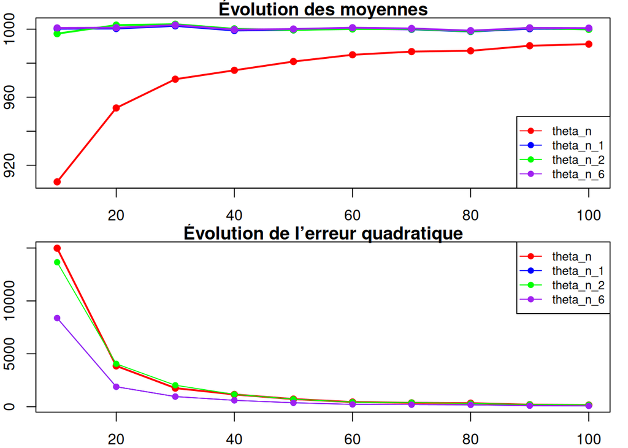

```r
#les tailles d'échantillons
n_values <- seq(10, 100, by=10)
theta = 1000  # Paramètre

# Initialisation des vecteurs de stockage des moyennes et erreurs quadratiques
moyenne_1 = numeric(length(n_values))
moyenne_2 = numeric(length(n_values))
moyenne_3 = numeric(length(n_values))
moyenne_4 = numeric(length(n_values))

erreur_1 = numeric(length(n_values))
erreur_2 = numeric(length(n_values))
erreur_3 = numeric(length(n_values))
erreur_4 = numeric(length(n_values))

# On tente plusieurs taille d'échantillon
for (j in seq_along(n_values)) {
    n = n_values[j]  # Taille de l'échantillon

    # Initialisations des vecteurs d'estimation
    theta_n = numeric(1000)
    theta_n_1 = numeric(1000)
    theta_n_2 = numeric(1000)
    theta_n_6 = numeric(1000)

    # Boucle des 1000 simulations
    for (i in 1:1000) {
        echantillon = sample(1:theta, n, replace=FALSE)  # Échantillon sans remise
        Xmax = max(echantillon)
        Xmin = min(echantillon)

        # Calcul des estimateurs
        theta_n[i] = Xmax
        theta_n_1[i] = (((n + 1) / n) * Xmax) - 1
        theta_n_2[i] = Xmax + Xmin - 1
        theta_n_6[i] = ((Xmax^(n + 1)) - ((Xmax - 1)^(n + 1))) / ((Xmax^n) - ((Xmax - 1)^n))
    }

    # calcul des moyennes
    moyenne_1[j] = mean(theta_n)
    moyenne_2[j] = mean(theta_n_1)
    moyenne_3[j] = mean(theta_n_2)
    moyenne_4[j] = mean(theta_n_6)

    # Calcul des erreurs quadratiques
    erreur_1[j] = var(theta_n) + (moyenne_1[j] - theta)^2
    erreur_2[j] = var(theta_n_1) + (moyenne_2[j] - theta)^2
    erreur_3[j] = var(theta_n_2) + (moyenne_3[j] - theta)^2
    erreur_4[j] = var(theta_n_6) + (moyenne_4[j] - theta)^2
}

# --- Affichage des résultats ---
par(mfrow=c(2,1), mar=c(2,2,1,1))



# Graphe des moyennes des estimateurs
plot(n_values, moyenne_1, type='o', col='red', pch=19, cex=0.8, lwd=2,
     xlab='Taille de l’échantillon n', ylab='Moyenne des estimateurs', main='Évolution des moyennes',
     ylim=c(min(c(moyenne_1, moyenne_2, moyenne_3, moyenne_4)), max(c(moyenne_1, moyenne_2, moyenne_3, moyenne_4))))
lines(n_values, moyenne_2, type='o', col='blue', pch=19, cex=0.8, lwd=2)
lines(n_values, moyenne_3, type='o', col='green', pch=19, cex=0.8, lwd=2)
lines(n_values, moyenne_4, type='o', col='purple', pch=19, cex=0.8, lwd=2)

legend("bottomright", legend=c("theta_n", "theta_n_1", "theta_n_2", "theta_n_6"),
       col=c("red", "blue", "green", "purple"), lty=1, pch=19, cex=0.8)

# Graphe des erreurs quadratiques
plot(n_values, erreur_1, type='o', col='red', pch=19, cex=0.8, lwd=2,
     xlab='Taille de l’échantillon n', ylab='Erreur quadratique', main='Évolution de l’erreur quadratique',
     ylim=c(min(c(erreur_1, erreur_2, erreur_3, erreur_4)), max(c(erreur_1, erreur_2, erreur_3, erreur_4))))
lines(n_values, erreur_2, type='o', col='blue', pch=19, cex=0.8, lwd=1)
lines(n_values, erreur_3, type='o', col='green', pch=19, cex=0.8, lwd=1)
lines(n_values, erreur_4, type='o', col='purple', pch=19, cex=0.8, lwd=1)

legend("topright", legend=c("theta_n", "theta_n_1", "theta_n_2", "theta_n_6"),
       col=c("red", "blue", "green", "purple"), lty=1, pch=19, cex= 0.8)
```

```r
par(mfrow=c(1,1))
```

**Question 4**

## Partie 3. Estimation du nombre d’iPhones 3G produits

**Question 1**

```r
iPhones <-read.table("iPhones.csv", sep=";", header=T)

# Définition de vecteurs contenant respectivement les codes TAC et les numéro TAC

codes_TAC  <- c(161200, 161300, 161400, 171200, 171300, 171400, 174200, 174300, 174400, 177100, 177300, 177400, 177500, 177600, 180900)
numeros_TAC <- 1:length(codes_TAC)

# Définition d'un dictionnaire faisant le lien entre code TAC et numéro TAC

dictionnaire_TAC  <- setNames(numeros_TAC,codes_TAC)

NS_list  <- c()

# Boucle et traitement sur tous les iPhones

for (iPhone in iPhones$IMEI) {
  tac_nb <- dictionnaire_TAC[substring(iPhone,3,8)]
  NS_list <- c(NS_list,(as.numeric(tac_nb)-1)*(10^6)+as.numeric(substring(iPhone,9,13))*10)
}
```

**Question 2**

Avec $X^*$ la valeur maximale des données observées

On a donc :

```r
# Trouver la valeur maximale des numéros de série
NS_max <- max(NS_list)

# Nombre total d'observations n
n <- length(NS_list)

# Estimateur du nombre total d'iPhones produits
theta <- ((n+1)/n) * NS_max - 1

print(paste("Estimation du nombre total d'iPhones produits :", round(theta)))
```

```
## [1] "Estimation du nombre total d'iPhones produits : 14887670"
```

**Question 3**

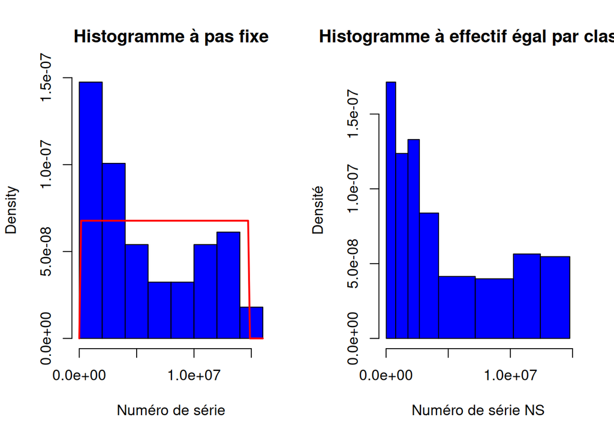

```r
par(mfrow=c(1,2))

# Premier histogramme : à pas fixe
hist(NS_list,
     main="Histogramme à pas fixe",
     col="blue",
     xlab="Numéro de série",
     probability=TRUE)

# Densité de la loi uniforme
curve(dunif(x, min(NS_list), max(NS_list)),
      add=TRUE, col="red", lwd=2)

# Deuxième histogramme : effectifs égaux (quantiles)
nb_classes <- 8
breaks_quantiles <- quantile(NS_list, probs = seq(0, 1, length.out = nb_classes + 1))

hist(NS_list,
     breaks = breaks_quantiles,
     main = "Histogramme à effectif égal par classe",
     xlab = "Numéro de série NS",
     ylab = "Densité",
     col = "blue",
     border = "black",
     probability=TRUE,
     include.lowest = TRUE)
```

En observant les deux histogrammes précédant, on voit bien que l’hypothèse d’uniformité des numéros de série sur la période 2008-2009 n’est pas respectée.

**Question 4**

On peut estimer le nombre d’iPhones produits sur chacune de ces sous-périodes en calculant l’estimateur trouvé pour l’exercice des chars allemands sans remise pour chaque période.  
Il faut toutefois faire attention à plusieurs points :  
- Les numéros de séries ne recommencent pas à 0 à chaque période  
- Le minimum/maximum du numéro de série d’une période n’est pas très représentatif puisqu’il n’y a pas eu d’observations de tous les iPhones d’une période.  
On peut se rapprocher de la réalité et tenter de résoudre le deuxième point en ajustant les numéros de série en calculant la médiane entre le max de la période précédante et le min de la période actuelle

```r
# Il y a 8 périodes de 4 semaines entre la semaine 25 de 2008 et la semaine 4 de 2009
nb_periodes = 8
periodes <- vector("list",nb_periodes)

# On parcourt tous les iPhones
for (i in 1:nrow(iPhones)) {
  pc_code <- as.character(iPhones$PC[i])
  ns <- NS_list[i]
  # On récupère le chiffre correspondant à l'année
  annee <- as.numeric(substring(pc_code, 3, 3))
  # On récupère le nombre correspondant à la semaine
  semaine <- as.numeric(substring(pc_code, 4, 5))
  # On récupère l'indice de la période par un calcul simple
  if (annee == 8){
    periode <- ceiling((semaine - 24) / 4)
  } else if (annee == 9) {
    periode <- 7 + ceiling(semaine / 4)
  }
  # On ajoute le numéro de série correspondant dans la bonne période
  periodes[[periode]] <- c(periodes[[periode]], ns)
}

# On calcul maintenant les estimateurs mois par mois et le nombre de téléphone produit théorique.

# On initialise des tableaux pour les numéros de séries min et max
ns_min_adj <- c()
ns_max_adj <- c()

# On parcourt les périodes pour trouver les bornes des numéros de séries par périodes
for (k in 1:nb_periodes){
  # On définit le minimum du numéro de série pour la période de lancement comme étant 0
  if (k == 1){
    ns_min <- 0
  } else {
    # Sinon, on ajuste le minimum à la médiane entre le minimum observé et le maximum observé précédant
    ns_min_prev <- max(periodes[[k-1]])
    ns_min <- floor((min(periodes[[k]]) + ns_min_prev) / 2)
  }
  # On définit le maximum du numéro de série pour la dernière période comme étant le maximum observé
  if (k == nb_periodes) {
    ns_max <- max(periodes[[k]])
  } else {
      # Sinon, on ajuste le maximum à la médiane entre le maximum observé avec le minimum observé suivant
    ns_max_next <- min(periodes[[k+1]])
    ns_max <- ceiling((max(periodes[[k]]) + ns_max_next) / 2)
  }
  # On ajoute nos valeurs dans nos tableaux de numéros de séries ajustés
  ns_min_adj <- c(ns_min_adj, ns_min)
  ns_max_adj <- c(ns_max_adj, ns_max)
}

# On initialise un tableau pour les estimateurs par mois
estimateurs_mois <- c()

# On parcourt à nouveau les périodes pour calculer les estimateurs
for (k in 1:nb_periodes) {
  # On récupère le nombre d'iPhones de la période ainsi que les numéros de série minmum et maximum ajustés
  n = length(periodes[[k]])
  ns_min <- ns_min_adj[k]
  ns_max <- ns_max_adj[k]
  # On calcule l'estimateur du mois
  estimateur_mois = round(((n+1)/n)*(ns_max - ns_min) - 1)
  # On l'ajoute au tableau des estimateurs
  estimateurs_mois <- c(estimateurs_mois,estimateur_mois)
}

resultats <- data.frame(
  Période = paste("Période", 1:length(estimateurs_mois)),   # Formater l'indice comme "Période 1", "Période 2", etc.
  Estimation = round(estimateurs_mois, 2)                   # Les estimations arrondies à 2 décimales
)

# Afficher le tableau
print(resultats)
```

```
##     Période Estimation
## 1 Période 1    1662841
## 2 Période 2    2834661
## 3 Période 3    3132594
## 4 Période 4    3152339
## 5 Période 5    2143895
## 6 Période 6    1104996
## 7 Période 7    1117703
## 8 Période 8     626699
```

```r
print(paste("Estimation du nombre total d'iPhones produit : ", sum(estimateurs_mois)))
```

```
## [1] "Estimation du nombre total d'iPhones produit :  15775728"
```

**Question 5**

On peut tracer un graphique nous permettant d’observer la variation de la production par période.

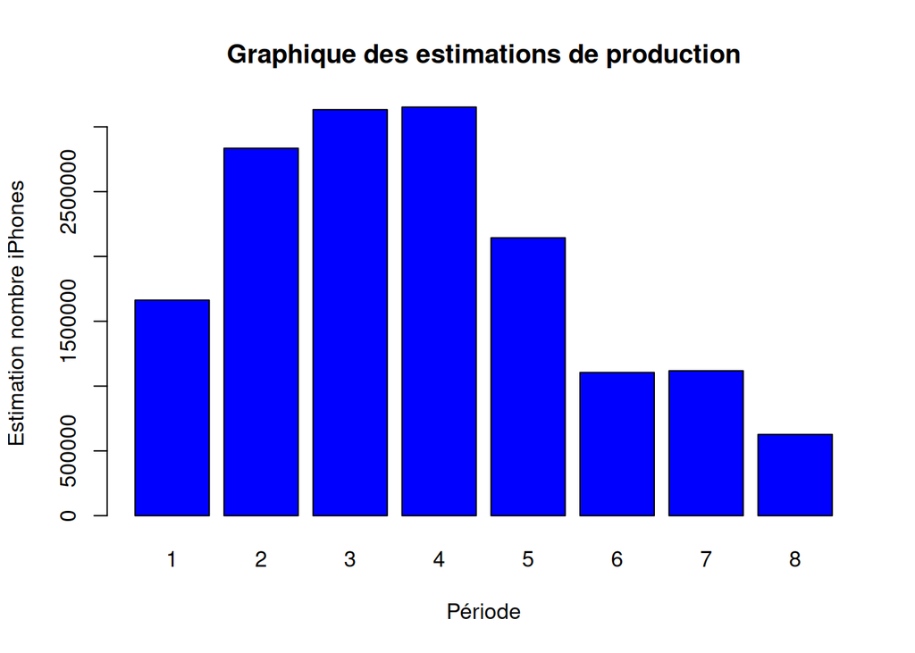

```r
# Création du graphe
barplot(estimateurs_mois, names.arg = 1:length(estimateurs_mois), col = "blue",
        xlab = "Période", ylab = "Estimation nombre iPhones", main = "Graphique des estimations de production")
```

On voit que la production n’est pas uniforme par période d’après les estimations effectuées et que l’estimation totale est plus élevée que lorsque l’on avait effectuée cette dernière sur toute la période.  
On peut toutefois remettre en question les calculs effectués pour les raisons suivantes :  
- La taille de l’échantillon est assez faible (139 pour une production totale estimée à environ 15 millions d’exemplaires).  
- Les estimations reposent sur l’étude des numéros de séries sur lesquels il ne semble pas y avoir d’uniformité.  
- Certains mois ont peu d’observations comme en témoignent le graphique suivant, ce qui rend peu fiable les estimations.

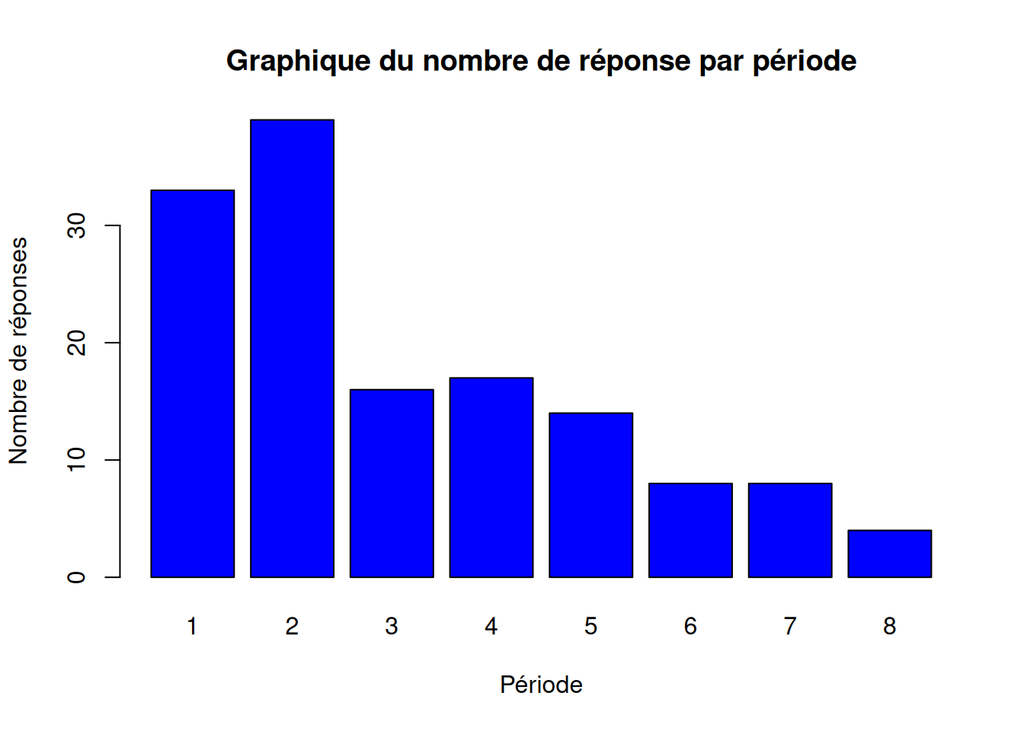

```r
# Création d'un tableau contenant le nombre de réponses par période
nb_rep_periode <- sapply(periodes,length)
# Création du graphe
barplot(nb_rep_periode, names.arg = 1:nb_periodes, col = "blue",
        xlab = "Période", ylab = "Nombre de réponses", main = "Graphique du nombre de réponse par période")
```

En conclusion, les estimations semblent relativement proche de la réalité mais ne peuvent pas être utilisées de manière fiable à cause d’un certain nombre d’hypothèses n’étant pas valides (taille de l’échantillon, uniformité des numéros de séries et uniformité de la répartition des réponses dans le temps).